# Mid-Term Exam #1

Due date: 6 October (11:59 pm)

Please read all of the questions and tables carefully and follow all instructions. Each question has an allotted point value. Be as thorough and specific as possible; extra calculations and incorrect information, even in the presence of correct information, will result in point deductions. Be sure to show all formulas and all necessary work to answer the questions. Upload your completed exam to the ELMs course site (attach to Exam #1) and to your Github repositories.

**Note**

While this is an open-note exam, you are not to receive assistance from anyone else. As usual, the Honor Code applies.

## Conceptual Questions

**Total points: 10**

Please include all work (and computations) necessary to answer the questions.

### Question 1

*1 point*

The following is a list of observed values, ordered from lowest to highest: 62, 63, 63, 64, 66, 67, 68, 68, 69, 70, 71, 72, 72, 74, 75, 76. What is an accurate five-number summary for these data?

```r
data <- c(62, 63, 63, 64, 66, 67, 68, 68, 69, 70, 71, 72, 72, 74, 75, 76)|>
  summary()

data
```

```
   Min. 1st Qu.  Median    Mean 3rd Qu.    Max.
  62.00   65.50   68.50   68.75   72.00   76.00
```

### Question 2

*1 point*

Suppose that the median, Q1, and Q3 from question #1 is an accurate representation of a second (hypothetical) distribution. Based on what this information tells you about this second distribution, which of the following numbers would be a suspected outlier?

1. 76
2. 62
3. 83
4. Both (A) and (C)
5. All of the above
6. None of the above, or cannot be determined from the information given.

Answer: C

### Question 3

*1 point*

The median age of ten people in a room is 50 years. One 40-year-old person leaves the room. What can we expect will happen to the median age for the remaining nine people? Do we know the median age of those nine people; if so, what is it?

*1 point*

The mean age of ten people in a room is 50 years. One 70-years-old person leaves the room. What can we expect will happen to the mean age for the remaining nine people? Do we know the mean age of those nine people; if so, what is it?

Answer: The mean age will decrease because it is not resistant and a larger number was removed. The new mean age of the remaining 9 people will be 47.78.

### Question 5

*1 point*

The mean age of ten people in a room is 50 years and the standard deviation is 3 years. One person leaves the room, and both the mean and the standard deviation become larger. What do we know about the age of that person?

Answer: That person was younfer than 50 years old.

### Question 6

*1 point*

The distribution of some variable has a median that is smaller than its mean. Which of the following statements about the distribution’s shape is most consistent with this information?

1. The shape of the distribution would be symmetric
2. The shape of the distribution would be skewed left
3. The shape of the distribution would be skewed right
4. None of the above – cannot be determined from the information given.

Answer: C

### Question 7

*1 point*

Suppose I want to test the hypothesis that the U.S. public’s approval of the president is higher when people have more positive perceptions of the U.S. economy. To test this hypothesis, I conduct a survey of individual-level attitudes. Which of the following research design strategies should I expect to exhibit both the greatest sampling variability (in the context of repeated sampling) and the lowest degree of expected sampling bias?

1. A random sample of 1,200 people from a list of all U.S. residential addresses
2. A random sample of 600 people from a list of all registered students at the University of Maryland
3. A random sample of 1,200 people from a list of all registered students at the University of Maryland
4. A random sample of 600 people from a list of all U.S. residential addresses.

*1 point*

Which of those research design strategies should I expect to exhibit the lowest degree of expected sampling bias?

A random sample of 1,200 people from a list of all U.S. residential addresses

### Question 9

*1 point*

I hypothesize that, as people become more conservative, they watch NASCAR more often. My measure of conservatism is a three category variable—not conservative, somewhat conservative, very conservative. My measure of NASCAR viewing is four category—none, occasionally, often, frequently. I construct a cross tab to examine this hypothesis. What distributions would I compare to test my hypothesis?

Answer: You would compare how much NASCAR viewing varies within each level of conservatism.

### Question 10

*1 point*

I examine the correlation between my independent variable and my dependent variable, and find a correlation coefficient of 0.9. What does this tell me about the causal effect of the IV on the DV?

Answer: The IV has a strong, positive causal effect on the DV.

## Applied Questions

Please include your R code. All data sets referenced below are available through the `polisciols` R package.

```r
library(tidyverse)
library(polisciols)
library(ggplot2)
library(dbplyr)
library(modelsummary)
```

**Total points: 20**

### Question 1

*5 points total*

I am interested in exploring US voters’ views of Donald Trump prior to the last US Presidential election. Use the `nes` data set in the `polisciols` R package to answer the following questions.

#### Part A

Plot the distribution of NES respondents’ answers to the following question: On a scale from 0 to 100, how would you rate Donald Trump? Describe that distribution. Include the five-number summary in your answer.

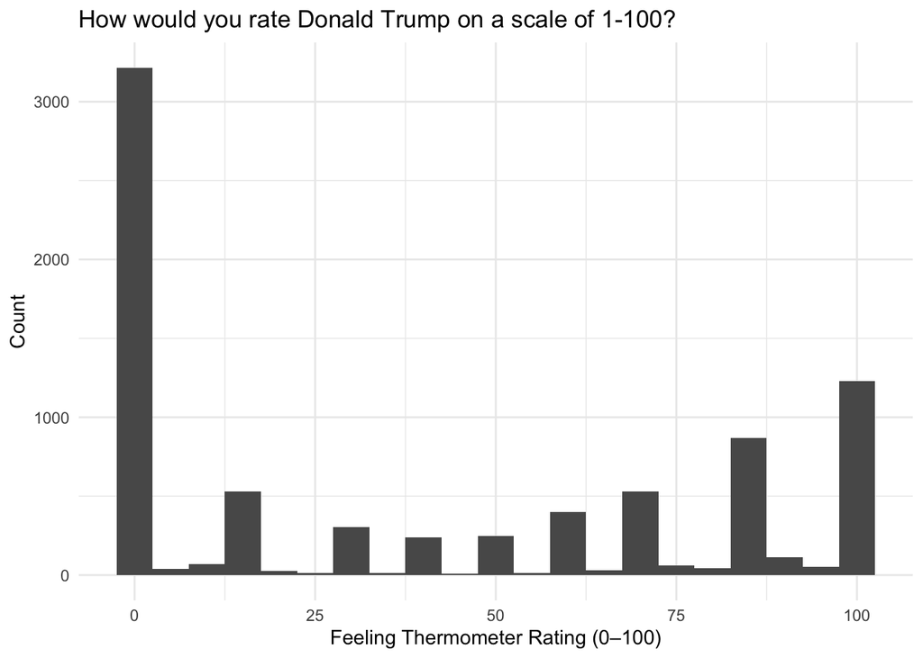

```r
ggplot(nes, aes(x = therm_trump)) +
  geom_histogram(binwidth = 5) +
  theme_minimal() +
  labs(
    title = "How would you rate Donald Trump on a scale of 1-100?",
    x = "Feeling Thermometer Rating (0–100)",
    y = "Count"
  )
```

```r
summary(nes$therm_trump)
```

```
   Min. 1st Qu.  Median    Mean 3rd Qu.    Max.    NA's
   0.00    0.00   30.00   40.44   85.00  100.00     232
```

**Note**

These responses are stored in the `therm_trump` variable.

#### Part B

If I were to select a respondent at random, what is the answer they most likely provided to this question?

Answer: 0

#### Part C

I hypothesize that people who hold different views about the size of the difference in incomes between rich people and poor people in the United States today compared to 20 years ago also have different views about Donald Trump. Group respondents based on their views about this difference and then plot, within each group, the respondents’ answers to the question about their views of Donald Trump.

**Note**

Respondents’ answer to the question - Do you think the difference in incomes between rich people and poor people in the United States today is larger, smaller, or about the same as it was 20 years ago? - are stored in the `income_gap` variable.

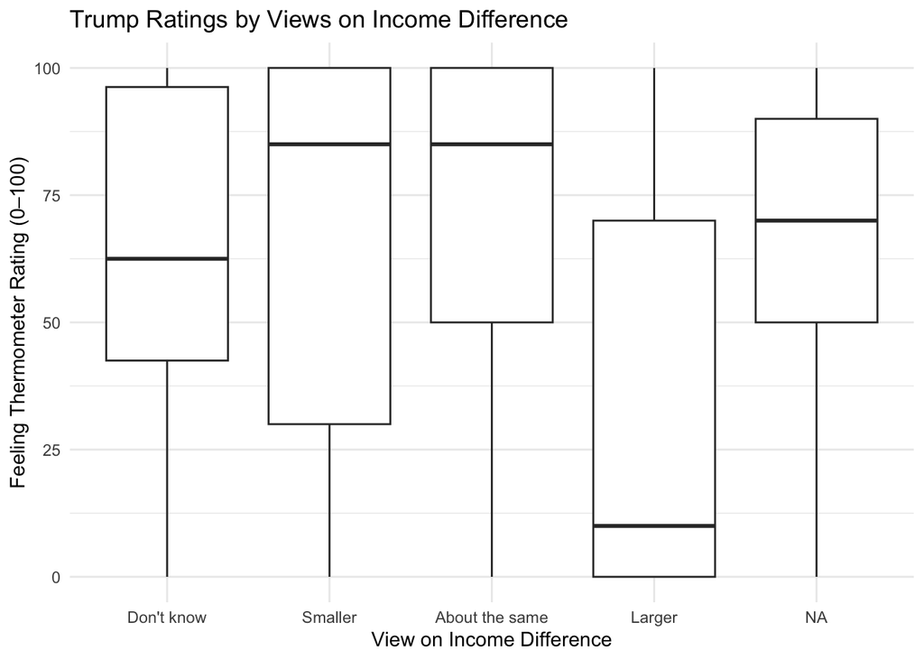

```r
ggplot(nes, aes(x = income_gap, y = therm_trump)) +
  geom_boxplot() +
  theme_minimal() +
  labs(
    title = "Trump Ratings by Views on Income Difference",
    x = "View on Income Difference",
    y = "Feeling Thermometer Rating (0–100)"
  )
```

#### Part D

Do these responses support my hypothesis?

Answer: Yes

#### Part E

If I were to select an individual who thought the difference in incomes between rich people and poor people in the United States today is **smaller** than it was 20 years ago, what is the most likely answer they provided to the question about their views of Donald Trump?

Answer: They most likely gave a high rating, above 75.

### Question 2

*5 points*

I hypothesize that providing free child care at election voting stations will increase turnout among families with young children. Design an experiment to test this hypothesis. Describe any shortcomings your experimental design may have.

Answer: There would be two variables. IV would be child care, DV would be voter turnout. The sample would be families with young children and adults who are eligible for voting. The project would be carried out in two randomly selected counties. The control group would be the county with no childcare, the control would be the county with free childcare at polling stations.Treatment would be randomly assigned to one of the two counties. I would create advertisements informing families of free childcare at voting stations and randomly select the families within the treatment county that would receive them. I would then compare if families were more likely to vote after they had knowledge of free childcare at voting stations.

Potential problems could include that those families that were randomly selected to receive the advertisements would spread the message via word of mouth, affecting the process of randomly selecting families.

### Question 3

*5 points*

I hypothesize that countries that share similar regime types are more likely to sign mutual defense agreements with each other than countries that do not share similar regimes. Use the `alliances_regime` data set from the `polisciols` R package to answer the following questions.

#### Part A

Construct a cross tab of these variables.

```r
datasummary_crosstab(regime_dyad ~ defense_agreement, data = alliances_regime)
```

| regime_dyad |  | No | Yes | All |
| --- | --- | --- | --- | --- |
| Joint | N | 7086 | 1047 | 8133 |
|  | % row | 87.1 | 12.9 | 100.0 |
| Mixed | N | 10122 | 660 | 10782 |
|  | % row | 93.9 | 6.1 | 100.0 |
| All | N | 17208 | 1707 | 18915 |
|  | % row | 91.0 | 9.0 | 100.0 |

#### Part B

Interpret your cross tab. Do these data support my hypothesis?

The results do support the initial hypothesis, the regimes that fell under the “joint” category had a higher count for “yes” than those who were in the “mixed” category.

### Question 4

*5 points*

I am interested in exploring the relationship between each country’s wealth and its renewable energy use. To do this, I collect data on each country’s GDP per capita (as a proxy for wealth) and the proportion of its overall energy consumption that is produced using renewable energy sources. Use the `renewables.csv` dataset published on ELMs to answer the following questions.

#### Part A

What proportion of overall energy consumption do the middle 50 percent of countries produce using renewable energy sources? Include an appropriate plot in your answer.

```r
renewables <- read_csv("renewables.csv")


q1 <- quantile(renewables$renewables_use, 0.25, na.rm = TRUE)
q3 <- quantile(renewables$renewables_use, 0.75, na.rm = TRUE)


cat("The middle 50% of countries use between",
    round(q1, 2), "and", round(q3, 2),
    "percent of their total energy from renewable sources.\n")
```

```
The middle 50% of countries use between 6.27 and 46.12 percent of their total energy from renewable sources.
```

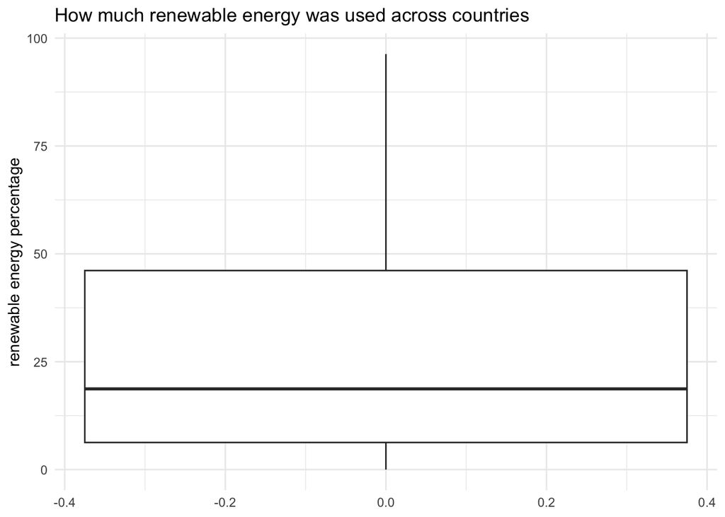

```r
ggplot(renewables, aes(y = renewables_use)) +
  geom_boxplot() +
  labs(
    title = "How much renewable energy was used across countries",
    y = "renewable energy percentage"
  ) +
  theme_minimal()
```

#### Part B

Describe the distribution of GDP per capita across countries globally. Include an appropriate plot in your answer.

Answer:

The distribution is skewed to the right.

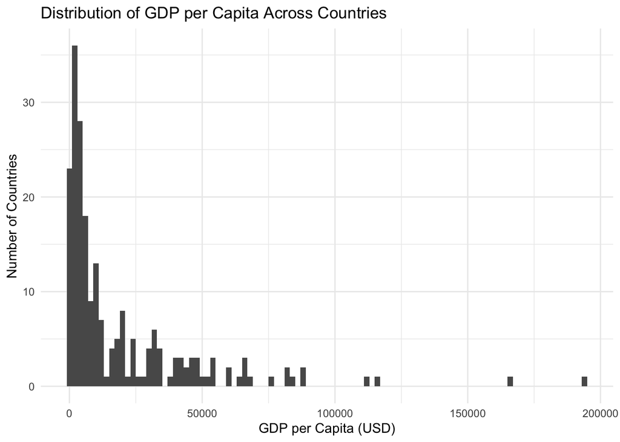

```r
ggplot(renewables, aes(x = gdp_per_cap)) +
  geom_histogram(binwidth = 2000) +
  labs(
    title = "Distribution of GDP per Capita Across Countries",
    x = "GDP per Capita (USD)",
    y = "Number of Countries"
  ) +
  theme_minimal()
```

#### Part C

Is the relationship between renewable energy use and wealth linear? What about the relationship between renewable energy use and each country’s logged GDP per capita? Include two plots (one of each relationship) in your answer.

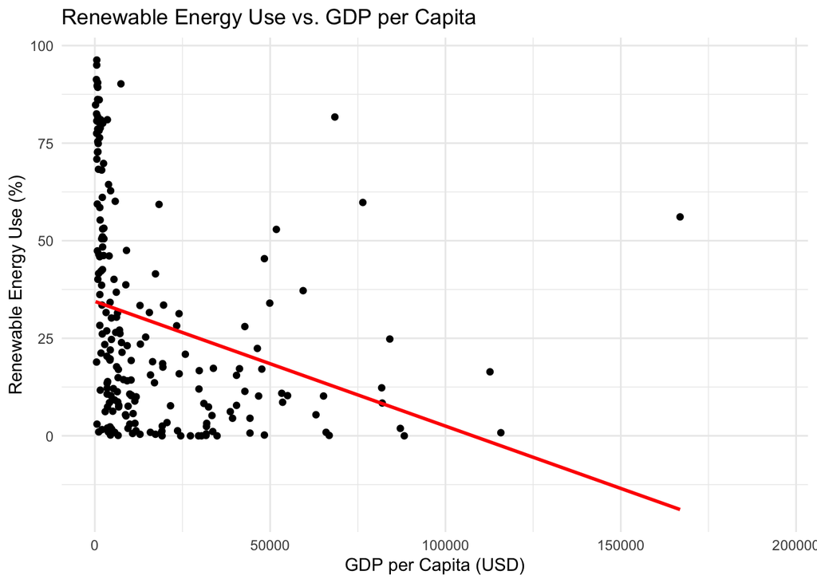

```r
ggplot(renewables, aes(x = gdp_per_cap, y = renewables_use)) +
  geom_point() +
  geom_smooth(method = "lm", se = FALSE, color = "red") +
  labs(
    title = "Renewable Energy Use vs. GDP per Capita",
    x = "GDP per Capita (USD)",
    y = "Renewable Energy Use (%)"
  ) +
  theme_minimal()
```

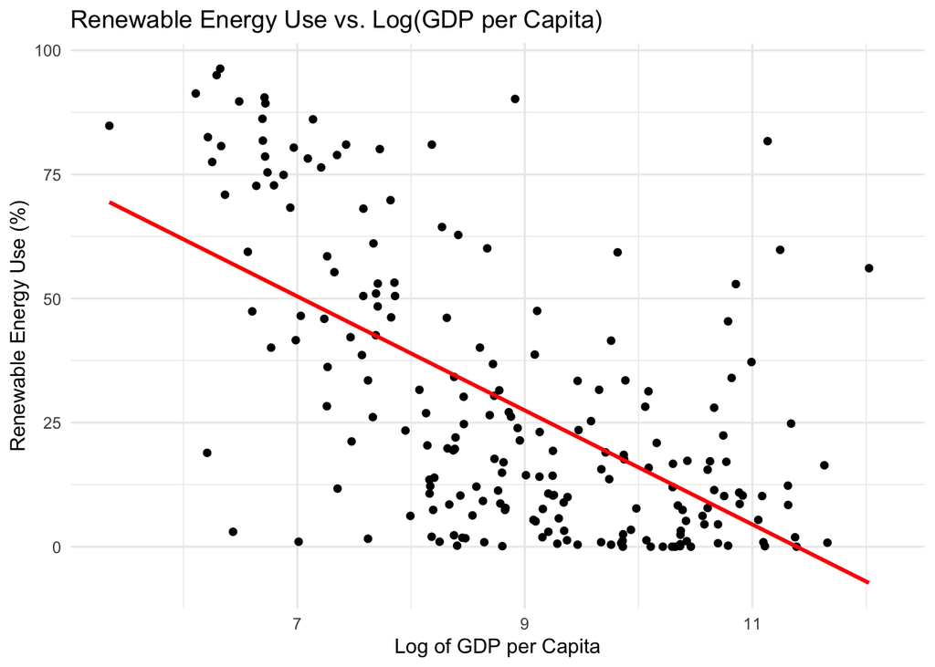

```r
ggplot(renewables, aes(x = log(gdp_per_cap), y = renewables_use)) +
  geom_point() +
  geom_smooth(method = "lm", se = FALSE, color = "red") +
  labs(
    title = "Renewable Energy Use vs. Log(GDP per Capita)",
    x = "Log of GDP per Capita",
    y = "Renewable Energy Use (%)"
  ) +
  theme_minimal()
```

Neither relationship is linear, the logged data comes closer to it.

#### Part D

Describe the direction and strength of the relationship between renewable energy use and wealth.

```r
cor(log(renewables$gdp_per_cap), renewables$renewables_use, use = "complete.obs")
```

```
[1] -0.6070358
```